# Unsupervised Learning PART 1_Automobile

```python
import pandas as pd
import numpy as np
import matplotlib.pyplot as plt
%matplotlib inline
from matplotlib import pyplot
import seaborn as sns
from sklearn.cluster import KMeans
```

Import and warehouse data:

```python
df_carname = pd.read_csv('Car name.csv')
```

```python
df_carname.head(10)
```

|  | car_name |
| --- | --- |
| 0 | chevrolet chevelle malibu |
| 1 | buick skylark 320 |
| 2 | plymouth satellite |
| 3 | amc rebel sst |
| 4 | ford torino |
| 5 | ford galaxie 500 |
| 6 | chevrolet impala |
| 7 | plymouth fury iii |
| 8 | pontiac catalina |
| 9 | amc ambassador dpl |

```python
df_carname.shape
```

```
(398, 1)
```

```python
df_carname.info()
```

```
<class 'pandas.core.frame.DataFrame'>
RangeIndex: 398 entries, 0 to 397
Data columns (total 1 columns):
 #   Column    Non-Null Count  Dtype
---  ------    --------------  -----
 0   car_name  398 non-null    object
dtypes: object(1)
memory usage: 3.2+ KB
```

```python
df_CarAttri = pd.read_json('Car-Attributes.json')
```

```python
df_CarAttri.head(10)
```

|  | mpg | cyl | disp | hp | wt | acc | yr | origin |
| --- | --- | --- | --- | --- | --- | --- | --- | --- |
| 0 | 18.0 | 8 | 307.0 | 130 | 3504 | 12.0 | 70 | 1 |
| 1 | 15.0 | 8 | 350.0 | 165 | 3693 | 11.5 | 70 | 1 |
| 2 | 18.0 | 8 | 318.0 | 150 | 3436 | 11.0 | 70 | 1 |
| 3 | 16.0 | 8 | 304.0 | 150 | 3433 | 12.0 | 70 | 1 |
| 4 | 17.0 | 8 | 302.0 | 140 | 3449 | 10.5 | 70 | 1 |
| 5 | 15.0 | 8 | 429.0 | 198 | 4341 | 10.0 | 70 | 1 |
| 6 | 14.0 | 8 | 454.0 | 220 | 4354 | 9.0 | 70 | 1 |
| 7 | 14.0 | 8 | 440.0 | 215 | 4312 | 8.5 | 70 | 1 |
| 8 | 14.0 | 8 | 455.0 | 225 | 4425 | 10.0 | 70 | 1 |
| 9 | 15.0 | 8 | 390.0 | 190 | 3850 | 8.5 | 70 | 1 |

```python
df_CarAttri.shape
```

```
(398, 8)
```

```python
df_CarAttri.info()
```

```
<class 'pandas.core.frame.DataFrame'>
RangeIndex: 398 entries, 0 to 397
Data columns (total 8 columns):
 #   Column  Non-Null Count  Dtype
---  ------  --------------  -----
 0   mpg     398 non-null    float64
 1   cyl     398 non-null    int64
 2   disp    398 non-null    float64
 3   hp      398 non-null    object
 4   wt      398 non-null    int64
 5   acc     398 non-null    float64
 6   yr      398 non-null    int64
 7   origin  398 non-null    int64
dtypes: float64(3), int64(4), object(1)
memory usage: 25.0+ KB
```

```python
df_final = pd.DataFrame.join(df_CarAttri,df_carname)
```

```python
df_final.head(10)
```

|  | mpg | cyl | disp | hp | wt | acc | yr | origin | car_name |
| --- | --- | --- | --- | --- | --- | --- | --- | --- | --- |
| 0 | 18.0 | 8 | 307.0 | 130 | 3504 | 12.0 | 70 | 1 | chevrolet chevelle malibu |
| 1 | 15.0 | 8 | 350.0 | 165 | 3693 | 11.5 | 70 | 1 | buick skylark 320 |
| 2 | 18.0 | 8 | 318.0 | 150 | 3436 | 11.0 | 70 | 1 | plymouth satellite |
| 3 | 16.0 | 8 | 304.0 | 150 | 3433 | 12.0 | 70 | 1 | amc rebel sst |
| 4 | 17.0 | 8 | 302.0 | 140 | 3449 | 10.5 | 70 | 1 | ford torino |
| 5 | 15.0 | 8 | 429.0 | 198 | 4341 | 10.0 | 70 | 1 | ford galaxie 500 |
| 6 | 14.0 | 8 | 454.0 | 220 | 4354 | 9.0 | 70 | 1 | chevrolet impala |
| 7 | 14.0 | 8 | 440.0 | 215 | 4312 | 8.5 | 70 | 1 | plymouth fury iii |
| 8 | 14.0 | 8 | 455.0 | 225 | 4425 | 10.0 | 70 | 1 | pontiac catalina |
| 9 | 15.0 | 8 | 390.0 | 190 | 3850 | 8.5 | 70 | 1 | amc ambassador dpl |

```python
df_final.shape
```

```
(398, 9)
```

```python
df_final.info()
```

```
<class 'pandas.core.frame.DataFrame'>
RangeIndex: 398 entries, 0 to 397
Data columns (total 9 columns):
 #   Column    Non-Null Count  Dtype
---  ------    --------------  -----
 0   mpg       398 non-null    float64
 1   cyl       398 non-null    int64
 2   disp      398 non-null    float64
 3   hp        398 non-null    object
 4   wt        398 non-null    int64
 5   acc       398 non-null    float64
 6   yr        398 non-null    int64
 7   origin    398 non-null    int64
 8   car_name  398 non-null    object
dtypes: float64(3), int64(4), object(2)
memory usage: 28.1+ KB
```

```python
df_final.to_csv('Car_mpg.csv', index = False)
```

```python
df_Car_mpg = pd.read_csv('Car_mpg.csv')
```

```python
df_Car_mpg.head(5)
```

|  | mpg | cyl | disp | hp | wt | acc | yr | origin | car_name |
| --- | --- | --- | --- | --- | --- | --- | --- | --- | --- |
| 0 | 18.0 | 8 | 307.0 | 130 | 3504 | 12.0 | 70 | 1 | chevrolet chevelle malibu |
| 1 | 15.0 | 8 | 350.0 | 165 | 3693 | 11.5 | 70 | 1 | buick skylark 320 |
| 2 | 18.0 | 8 | 318.0 | 150 | 3436 | 11.0 | 70 | 1 | plymouth satellite |
| 3 | 16.0 | 8 | 304.0 | 150 | 3433 | 12.0 | 70 | 1 | amc rebel sst |
| 4 | 17.0 | 8 | 302.0 | 140 | 3449 | 10.5 | 70 | 1 | ford torino |

Data cleansing:

```python
df_Car_mpg.shape
```

```
(398, 9)
```

```python
df_Car_mpg.info()
```

```
<class 'pandas.core.frame.DataFrame'>
RangeIndex: 398 entries, 0 to 397
Data columns (total 9 columns):
 #   Column    Non-Null Count  Dtype
---  ------    --------------  -----
 0   mpg       398 non-null    float64
 1   cyl       398 non-null    int64
 2   disp      398 non-null    float64
 3   hp        398 non-null    object
 4   wt        398 non-null    int64
 5   acc       398 non-null    float64
 6   yr        398 non-null    int64
 7   origin    398 non-null    int64
 8   car_name  398 non-null    object
dtypes: float64(3), int64(4), object(2)
memory usage: 28.1+ KB
```

```python
df_Car_mpg['hp'].unique()
```

```
array(['130', '165', '150', '140', '198', '220', '215', '225', '190',
       '170', '160', '95', '97', '85', '88', '46', '87', '90', '113',
       '200', '210', '193', '?', '100', '105', '175', '153', '180', '110',
       '72', '86', '70', '76', '65', '69', '60', '80', '54', '208', '155',
       '112', '92', '145', '137', '158', '167', '94', '107', '230', '49',
       '75', '91', '122', '67', '83', '78', '52', '61', '93', '148',
       '129', '96', '71', '98', '115', '53', '81', '79', '120', '152',
       '102', '108', '68', '58', '149', '89', '63', '48', '66', '139',
       '103', '125', '133', '138', '135', '142', '77', '62', '132', '84',
       '64', '74', '116', '82'], dtype=object)
```

We can see that there is a '?' mark in the value hence we are getting type for hp as object type

```python
df_Car_mpg['hp'].value_counts()
```

```
150    22
90     20
88     19
110    18
100    17
       ..
49      1
113     1
122     1
208     1
132     1
Name: hp, Length: 94, dtype: int64
```

```python
df_Car_mpg['hp'].mode()
```

```
0    150
dtype: object
```

```python
df_Car_mpg['hp'].replace('?','150',inplace=True)
```

```python
df_Car_mpg['hp'].value_counts()
```

```
150    28
90     20
88     19
110    18
100    17
       ..
122     1
102     1
54      1
91      1
208     1
Name: hp, Length: 93, dtype: int64
```

```python
df_Car_mpg['hp']= df_Car_mpg['hp'].astype('int64')
```

```python
df_Car_mpg.dtypes
```

```
mpg         float64
cyl           int64
disp        float64
hp            int64
wt            int64
acc         float64
yr            int64
origin        int64
car_name     object
dtype: object
```

```python
df_Car_mpg.isnull().sum()
```

```
mpg         0
cyl         0
disp        0
hp          0
wt          0
acc         0
yr          0
origin      0
car_name    0
dtype: int64
```

Data analysis & visualisation:

```python
df_Car_mpg.describe()
```

|  | mpg | cyl | disp | hp | wt | acc | yr | origin |
| --- | --- | --- | --- | --- | --- | --- | --- | --- |
| count | 398.000000 | 398.000000 | 398.000000 | 398.000000 | 398.000000 | 398.000000 | 398.000000 | 398.000000 |
| mean | 23.514573 | 5.454774 | 193.425879 | 105.155779 | 2970.424623 | 15.568090 | 76.010050 | 1.572864 |
| std | 7.815984 | 1.701004 | 104.269838 | 38.600986 | 846.841774 | 2.757689 | 3.697627 | 0.802055 |
| min | 9.000000 | 3.000000 | 68.000000 | 46.000000 | 1613.000000 | 8.000000 | 70.000000 | 1.000000 |
| 25% | 17.500000 | 4.000000 | 104.250000 | 76.000000 | 2223.750000 | 13.825000 | 73.000000 | 1.000000 |
| 50% | 23.000000 | 4.000000 | 148.500000 | 95.000000 | 2803.500000 | 15.500000 | 76.000000 | 1.000000 |
| 75% | 29.000000 | 8.000000 | 262.000000 | 130.000000 | 3608.000000 | 17.175000 | 79.000000 | 2.000000 |
| max | 46.600000 | 8.000000 | 455.000000 | 230.000000 | 5140.000000 | 24.800000 | 82.000000 | 3.000000 |

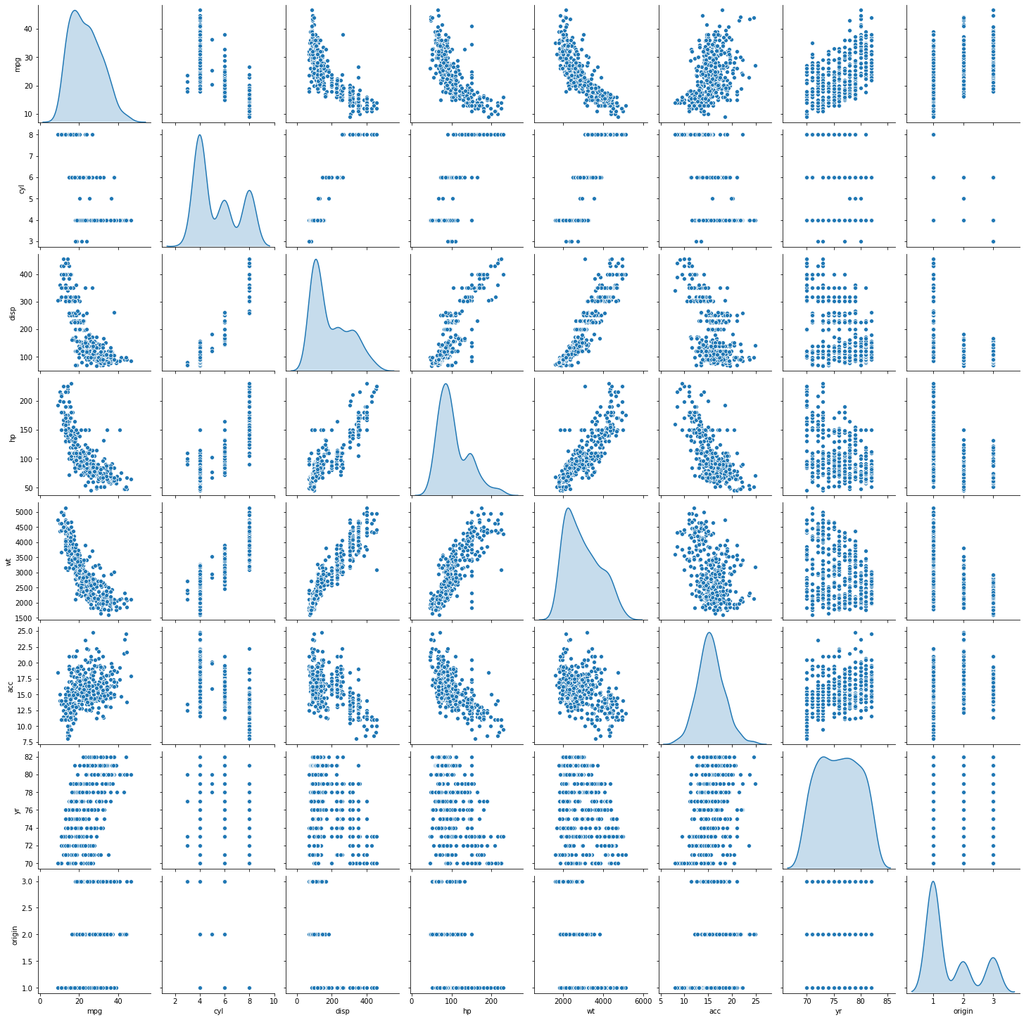

```python
sns.pairplot(df_Car_mpg, diag_kind='kde')
```

expect three to four clusters from the pair panel visual inspection

```python
df_Car_mpg= df_Car_mpg.drop('car_name', axis =1)
```

```python
df_Car_mpg.info()
```

```
<class 'pandas.core.frame.DataFrame'>
RangeIndex: 398 entries, 0 to 397
Data columns (total 8 columns):
 #   Column  Non-Null Count  Dtype
---  ------  --------------  -----
 0   mpg     398 non-null    float64
 1   cyl     398 non-null    int64
 2   disp    398 non-null    float64
 3   hp      398 non-null    int64
 4   wt      398 non-null    int64
 5   acc     398 non-null    float64
 6   yr      398 non-null    int64
 7   origin  398 non-null    int64
dtypes: float64(3), int64(5)
memory usage: 25.0 KB
```

```python
from scipy.stats import zscore

df_Car_mpg = df_Car_mpg.loc[:, 'mpg':'origin']
df_Car_mpg_z = df_Car_mpg.apply(zscore)
```

```python
cluster_range = range( 1, 10)
cluster_errors = []
for num_clusters in cluster_range:
  kmeans = KMeans( num_clusters, n_init = 10)
  kmeans.fit(df_Car_mpg_z)
  cluster_errors.append(kmeans.inertia_ )
```

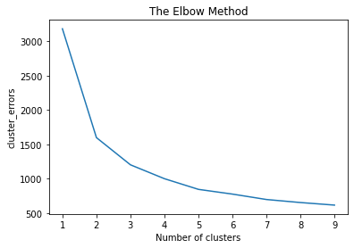

```python
plt.plot(range(1,10),cluster_errors)
plt.title('The Elbow Method')
plt.xlabel('Number of clusters')
plt.ylabel('cluster_errors')
plt.show()
```

The elbow plot confirms our visual analysis that there is likely 3 clusters

```python
kmeans = KMeans( n_clusters = 3, random_state = 7 )
kmeans.fit(df_Car_mpg_z)

prediction=kmeans.predict(df_Car_mpg_z)
df_Car_mpg_z["GROUP"] = prediction
```

[output not shown]

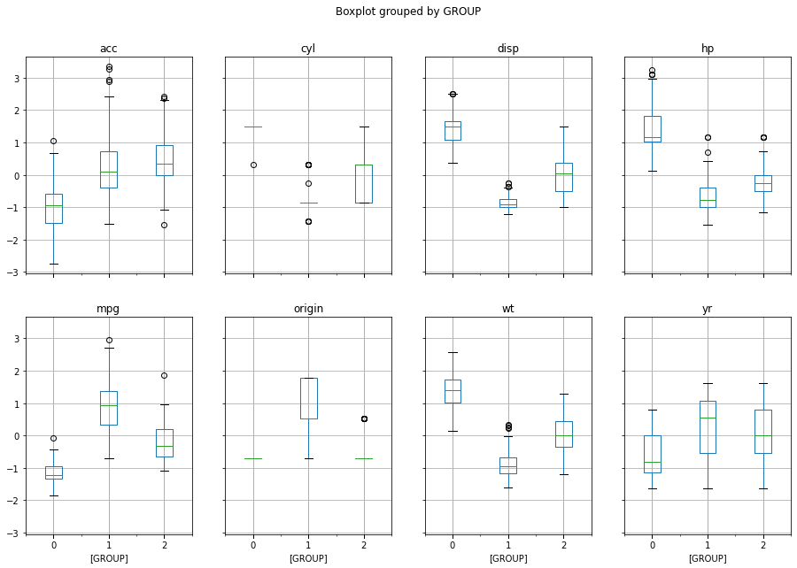

```python
df_Car_mpg_z.boxplot(by = 'GROUP',  layout=(2,4), figsize=(15, 10))
```

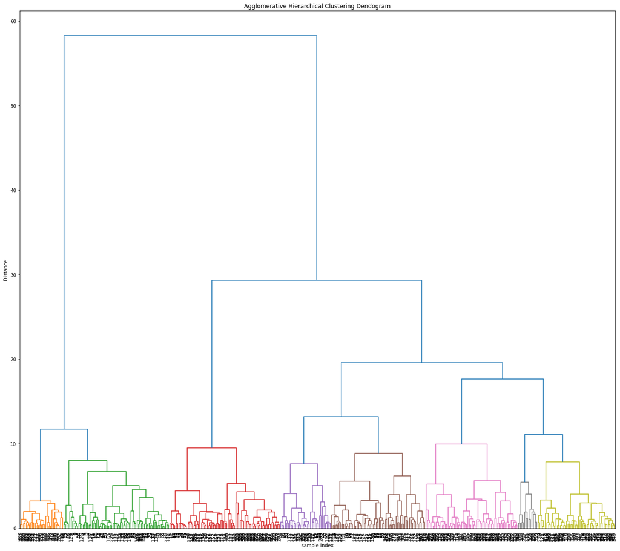

```python
from scipy.cluster.hierarchy import dendrogram, linkage
from scipy.spatial.distance import pdist
plt.figure(figsize=(18, 16))
plt.title('Agglomerative Hierarchical Clustering Dendogram')
plt.xlabel('sample index')
plt.ylabel('Distance')
Z = linkage(df_Car_mpg_z, 'ward')
dendrogram(Z,leaf_rotation=90.0,p=20,color_threshold=10,leaf_font_size=10,truncate_mode='level')
plt.tight_layout()
```

In hierarchical clustering it's appropriate by interpreting the dendrogram where as in K Means clustering, since one start with random choice of clusters, the results produced by running the algorithm many times may differ.

Three optimal clusters are present in the data

```python
df_Car_mpg_z.sample(5)
```

|  | mpg | cyl | disp | hp | wt | acc | yr | origin | GROUP |
| --- | --- | --- | --- | --- | --- | --- | --- | --- | --- |
| 96 | -1.346959 | 1.498191 | 1.599540 | 1.811667 | 1.005673 | -1.658577 | -0.815074 | -0.715145 | 0 |
| 378 | 1.855641 | -0.856321 | -0.849116 | -1.093465 | -0.999583 | -0.315185 | 1.621983 | -0.715145 | 1 |
| 109 | -0.322127 | -0.856321 | -0.513026 | -0.860017 | -0.673256 | 1.427593 | -0.815074 | -0.715145 | 2 |
| 199 | -0.450231 | 0.320935 | 0.303193 | -0.133734 | 0.804675 | 0.774051 | -0.002721 | -0.715145 | 2 |
| 21 | 0.062185 | -0.856321 | -0.829911 | -0.393121 | -0.638968 | -0.387801 | -1.627426 | 0.533222 | 1 |

```python
from sklearn.linear_model import LinearRegression
```

```python
df_Car_mpg_z_Group0= df_Car_mpg_z[df_Car_mpg_z['GROUP'] == 0]
```

```python
df_Car_mpg_z_Group1= df_Car_mpg_z[df_Car_mpg_z['GROUP'] == 1]
```

```python
df_Car_mpg_z_Group2= df_Car_mpg_z[df_Car_mpg_z['GROUP'] == 2]
```

```python
from sklearn.model_selection import train_test_split
```

```python
X0 = df_Car_mpg_z_Group0.drop(['mpg','GROUP'], axis=1)

y0 = df_Car_mpg_z_Group0['mpg']
```

```python
X_train, X_test, y_train, y_test = train_test_split(X0, y0, test_size=0.30, random_state=1)
```

```python
regression_model = LinearRegression()
regression_model.fit(X_train, y_train)
```

```
LinearRegression()
```

```python
regression_model_pred = regression_model.predict(X_test)
```

```python
r_sq = regression_model.score(X_test, y_test)
```

```python
print('Coefficient for Group0: \n', r_sq)
```

```
Coefficient for Group0:
 0.6895616908671176
```

```python
X1 = df_Car_mpg_z_Group1.drop(['mpg','GROUP'], axis=1)

y1 = df_Car_mpg_z_Group1['mpg']
```

```python
X_train, X_test, y_train, y_test = train_test_split(X1, y1, test_size=0.30, random_state=1)
regression_model = LinearRegression()
regression_model.fit(X_train, y_train)
regression_model_pred = regression_model.predict(X_test)
r_sq = regression_model.score(X_test, y_test)
```

```python
print('Coefficient for Group1: \n', r_sq)
```

```
Coefficient for Group1:
 0.6396003734351106
```

```python
X2 = df_Car_mpg_z_Group2.drop(['mpg','GROUP'], axis=1)

y2 = df_Car_mpg_z_Group2['mpg']
```

```python
X_train, X_test, y_train, y_test = train_test_split(X2, y2, test_size=0.30, random_state=1)
regression_model = LinearRegression()
regression_model.fit(X_train, y_train)
regression_model_pred = regression_model.predict(X_test)
r_sq = regression_model.score(X_test, y_test)
```

```python
print('Coefficient for Group2: \n', r_sq)
```

```
Coefficient for Group2:
 0.5751857896485287
```

When the clustering method is used then all the data is grouped as per the similarity. Thus it becomes easy to replace the missing data and find the hyper plane which distinguish among the data.

Few models might be effective for certain type of data group and not for the other group thus reducing the over all efficiency of the model. Hence using different models might prove to be much more efficient.

As seen in the above case linear regression was giving better result for certain group and not for the others.

The Data collected by the company could be much more accurate with less number of miss. Also the data could have been in a single file instead of multiple file with proper index.

--------------------------END----------------------------